# temp-159699033139760466

## 1. Các mô hình tuyến tính thường gặp:

Hai mô hình tuyến tính (linear models) Linear Regression và Perceptron Learning Algorithm (PLA) là các mô hình tuyến tính thường gặp chúng đều có chung một dạng:

$y = f(W^TX)$

Với $f(s)$ là một hàm kích hoạt. Với $f(s) = s$ trong linear regression, và $f(s) = sgn(s)$ trong PLA.

Trong linear regression, tích vô hướng $W^TX$ được trực tiếp sử dụng để dự đoán output $y$, loại này phù hợp nếu chúng ta cần dự đoán một giá trị thực của đầu ra không bị chặn trên và dưới. Trong PLA, đầu ra chỉ nhận một trong hai giá trị $1$ hoặc $-1$, phù hợp với các bài toán *binary classification*.

Với các bài toán *flexible* hơn ta có một mô hình khác với một activation khác. Trong mô hình này, đầu ra có thể được thể hiện dưới dạng xác suất *(probability)*.

Mô hình này có tên là *logistic regression*. Mặc dù trong tên có chứa từ *regression*, *logistic regression* thường được sử dụng nhiều hơn cho các bài toán phân lớp.

## 2. Tính chất của mô hình Logistic Regression

Mô hình Logistic Regression có một vài tính chất quan trọng:

– Là các hàm số liên tục nhận giá trị thực, bị chặn trong khoảng (0, 1).

– Nếu coi điểm có tung độ là 1/2 là ngưỡng, các điểm càng xa ngưỡng về phía bên trái có giá trị càng gần 0, các điểm càng xa ngưỡng về phía bên phải có giá trị càng gần 1.

– Hai hàm này có đạo hàm mọi nơi, vì vậy có thể được lợi trong việc tối ưu.

## 3. Sigmoid function

Trong số các hàm số có 3 tính chất nói trên thì hàm sigmoid:

$$f(s) = \frac{1}{1 + e^{-s}} \triangleq \sigma(s)$$

được sử dụng nhiều nhất, vì nó bị chặn trong khoảng $(0,1)$. Hơn nữa:

$$\lim_{s \rightarrow -\infty}\sigma(s) = 0; ~~ \lim_{s \rightarrow +\infty}\sigma(s) = 1 $$

Đặc biệt hơn nữa:

$$\begin{eqnarray} \sigma’(s) &=& \frac{e^{-s}}{(1 + e^{-s})^2} \\ &=& \frac{1}{1+ e^{-s}} \frac{e^{-s}}{1 + e^{-s}} \\ &=& \sigma(s)(1 - \sigma(s)) \end{eqnarray}$$

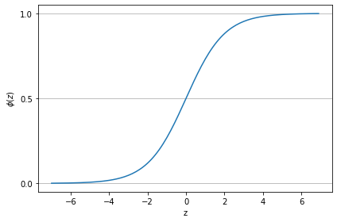

```python
import matplotlib.pyplot as plt
import numpy as np


def sigmoid(z):
    return 1.0 / (1.0 + np.exp(-z))

z = np.arange(-7, 7, 0.1)
phi_z = sigmoid(z)

plt.plot(z, phi_z)
# plt.axvline(0.0, color='k')
# plt.ylim(-0.1, 1.1)
plt.xlabel('z')
plt.ylabel('$\phi (z)$')

# y axis ticks and gridline
plt.yticks([0.0, 0.5, 1.0])
ax = plt.gca()
ax.yaxis.grid(True)

plt.tight_layout()
#plt.savefig('images/03_02.png', dpi=300)
plt.show()
```

Output của hàm sigmoid là xác suất của một điểm dữ liệu

Ví dụ:

Bộ dữ liệu có 2 lớp cần phân loại là đỏ và xanh dương

kết quả $\phi(z) = P(y=\color{red}{\text{red}}|x;w) = 0.8$ của một điểm dữ liệu, có nghĩa xác suất điểm này thuộc vào lớp mày đỏ là 80%. Do đó xác suất điểm này thuộc class $\color{blue}{\text{blue}}$ là $P(y=\color{blue}{\text{blue}}|x;w) = 1 - P(y=\color{red}{\text{red}}|x;w) = 0.2.$

Xác suất dự đoán sau đó có thể được chuyển thành một kết quả nhị phân thông qua một threshold function:

$$\hat y = \begin{cases} 1 & if \phi(z) \geq 0.5 \\ 0 & otherwise \end{cases}$$

Tương tự, cũng có:

$$\hat y = \begin{cases} 1 & if z \geq 0 \\ 0 & otherwise \end{cases}$$

Trong thực tế, *Logistic Regression* được sử dụng nhiều trong các bài toán liên quan đến xác suất như: Dự báo thời tiết, không chỉ để dự đoán liệu nó có mưa hay không vào một ngày cụ thể mà còn để tính toán khả năng mưa. Tương tự, có thể được sử dụng để dự đoán khả năng bệnh nhân mắc một bệnh cụ thể với các triệu chứng nhất định, đó là lý do *Logistic Regression* rất phổ biến trong lĩnh vực y học.

## 4. Hàm mất mát và phương pháp tối ưu

## 4.1 Hàm mất mát

*Logistic Regression* sử dụng maximize **likelihood** để ước tính được **w**.

Nếu như MSE là phương pháp được sử dụng để ước tính các tham số trong Adaline thì Logistic regression sử dụng maximun likelihood để ước tính tham số w.

- Xét N mẫu dữ liệu được gán nhãn 0 hoặc 1:
  - Với mẫu dữ liệu được gán nhãn 1: chúng ta muốn ước tính tham số W sao cho giá trị đầu ra $\phi{(z)}$ gần với xác suất là 1 nhất có thể.
  - Với mẫu dữ liệu được gán nhãn 0: chúng ta muốn ước tính tham số W sao cho giá trị đầu ra $1 - \phi{(z)}$ gần với xác suất là 1 nhất có thể.
- Tóm lại:
  - Với tất cả mẫu có nhãn 1, chúng ta muốn ước tính $\hat{y}$ sao cho tích của tất cả xác suất có điền kiệu của các mẫu này sao cho gần 1 nhất có thể. Nghĩa là cần maximize $\prod_{ i \in \{y = 1\}} \phi{(z^{(i)})}$ (1)
  - Tương tự với tất cả mẫu có nhãn 0, ta cần maximize $\prod_{ i \in \{y = 0\}} 1 - \phi{(z^{(i)})}$ (2)
- Kết hợp (1) và (2) ta muốn ước tính W sao cho maximize hàm $L(w) = \prod_{ i \in \{y = 1\}} \phi{(z^{(i)})} \times \prod_{ i \in \{y = 0\}} 1 - \phi{(z^{(i)})}$ cho toàn bộ dataset.

$L(w) = \prod_{ i \in \{y = 1\}} \phi{(z^{(i)})} \times \prod_{ i \in \{y = 0\}} 1 - \phi{(z^{(i)})} = \prod_i^n {\phi{(z^{(i)})}}^{y^{(i)}} \times (1 - \phi{(z^{(i)})}) ^{1 - y^{(i)}} $ gọi là **likelihood function**

Trong thực thế, maximize logarit cơ số e của hàm này dễ dàng hơn.

**log-likelihood function**: $l(w) = \log{L(w)} = \sum_{i = 1}^n [ y^{(i)}\log{({\phi{(z^{(i)})}})} + (1 - y^{(i)})\log{(1 - \phi{(z^{(i)})})}]$

- Sử dụng log để giảm thiểu khả năng xảy ra lỗi *numberical underflow*, có thể xảy ra khi hàm likelihood quá nhỏ $~ 10^{-123}$.
- Log còn dùng để chuyển đổi dấu $\times$ thành $+$ điều này làm cho việc đạo hàm dễ dàng hơn.

Bây giờ có thể sử dụng GD để maximize log-likelihood function hay minimize nó khi viết dưới dạng *cost function* như ở chapter 2: $$J(W) = \sum_{i = 1}^n [- y^{(i)}\log{({\phi{(z^{(i)})}})} - (1 - y^{(i)})\log{(1 - \phi{(z^{(i)})})}]$$

*Cost function* một mẫu dữ liệu: $$j(\phi(z),y;w) = - y\log{({\phi{(z)}})} - (1 - y)\log{(1 - \phi{(z)})}$$

Nhìn vào công thức trên, có thể thấy rằng:

$$j(\phi(z),y;w) = \begin{cases} -\log(\phi(z)) & if &y =1 \\ -\log(1- \phi(z)) & if & y =0 \end{cases}$$

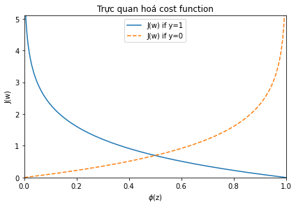

```python
def cost_1(z):
    return - np.log(sigmoid(z))


def cost_0(z):
    return - np.log(1 - sigmoid(z))

z = np.arange(-10, 10, 0.1)
phi_z = sigmoid(z)

c1 = [cost_1(x) for x in z]
plt.plot(phi_z, c1, label='J(w) if y=1')

c0 = [cost_0(x) for x in z]
plt.plot(phi_z, c0, linestyle='--', label='J(w) if y=0')

plt.ylim(0.0, 5.1)
plt.xlim([0, 1])
plt.xlabel('$\phi$(z)')
plt.ylabel('J(w)')
plt.legend(loc='best')
plt.tight_layout()
plt.title("Trực quan hoá cost function")
plt.show()
```

## 4.2 Tối ưu hàm mất mát

Hàm mất mát với chỉ một điểm dữ liệu $(x_i; y_i)$là: $$j(\phi(z),y;w) = - y\log{({\phi{(z)}})} - (1 - y)\log{(1 - \phi{(z)})}\\ = -(y_i\log{({\phi{(z)}})} + (1 - y)\log{(1 - \phi{(z)})}$$

Với đạo hàm:

\begin{eqnarray} \frac{\partial j(\phi(z),y;w)}{\partial w} &=& -(\frac{y_i}{\phi{(z)}} - \frac{1- y_i}{1 - \phi{(z)}} ) \frac{\partial \phi{(z)}}{\partial w} \\ &=& \frac{\phi{(z)} - y_i}{\phi{(z)}(1 - \phi{(z)})} \frac{\partial \phi{(z)}}{\partial w} \end{eqnarray}

chúng ta sẽ tìm hàm $\phi(z) = f(w^Tx)$ sao cho mẫu số bị triệt tiêu. Nếu đặt $s=w^Tx$, chúng ta sẽ có:

$$\frac{\partial z_i}{\partial \mathbf{w}} = \frac{\partial z_i}{\partial s} \frac{\partial s}{\partial \mathbf{w}} = \frac{\partial z_i}{\partial s} \mathbf{x}$$

Một cách trực quan nhất, ta sẽ tìm hàm số $\phi(z) = f(s)$ sao cho:

$$\frac{\partial z}{\partial s} = z(1 - z)$$$$\begin{eqnarray} &\frac{\partial z}{z(1-z)} &=& \partial s \\ \Leftrightarrow & (\frac{1}{z} + \frac{1}{1 - z})\partial z &=&\partial s \\ \Leftrightarrow & \log z - \log(1 - z) &=& s + C\\ \Leftrightarrow & \log \frac{z}{1 - z} &=& s + C\\ \Leftrightarrow & \frac{z}{1 - z} &=& e^{s + C} \\ \Leftrightarrow & z &=& e^{s + C} (1 - z) \\ \Leftrightarrow & z = \frac{e^{s + C}}{1 +e^{s + C}} &=&\frac{1}{1 + e^{-s - C}} = \sigma(s) \end{eqnarray}$$

Với C là hằng số. Chọn $C = 0$ ta được $\phi(z) = f(w^Tx) = \sigma(s)$

Nhận thấy: $$\frac{\partial j(\phi(z),y;w)}{\partial w} = (\phi(z)-y_i)x_i $$

Sử dụng GD, chúng ta có thể update $w$ theo cách đi ngược chiều gradient: $$w=w+\eta{(y_i - \phi(z))x_i}$$